```python
from sympy import*
from IPython.display import Image, display, HTML
from scipy import optimize
import matplotlib.pyplot as plt
import numpy as np
```

# Homework 2

## 1.1 Composition of Transformations

```python
x, y, z, theta, phi, psi, x_p, y_p, z_p, nu, dx, dy, dz=symbols('x y z theta phi psi x^{\prime} y^{\prime} z^{\prime} nu dx dy dz')
```

```python
HR_X_G_phi=Matrix([[1,0,0,0],
                   [0,cos(phi),-sin(phi),0],
                   [0,sin(phi),cos(phi),0],
                   [0,0,0,1]])
HT_Y_L_y=Matrix([[1,0,0,0],
                   [0,1,0,y],
                   [0,0,1,0],
                   [0,0,0,1]])
HR_Z_G_theta=Matrix([[cos(theta),-sin(theta),0,0],
                   [sin(theta),cos(theta),0,0],
                   [0,0,1,0],
                   [0,0,0,1]])
HR_X_G_psi=Matrix([[1,0,0,0],
                   [0,cos(psi),-sin(psi),0],
                   [0,sin(psi),cos(psi),0],
                   [0,0,0,1]])
```

The multiplication order is the following based on the frame that we are working with. In the first group are the rotation around the world frame in order STEP_3*STEP_1 according to the rules of extrinsic rotation in the second group are the rotations/translations around/along the current frame in the order of STEP_2*STEP*4 according to the rules of intrinsict transformations. $$ R*{\theta}{\cdot}R*{\phi}{\cdot}T*{y}{\cdot}R_{\psi} $$

```python
simplify(HR_Z_G_theta*HR_X_G_phi*HT_Y_L_y*HR_X_G_psi) #.subs({y:5,phi:pi/2,theta:pi/2,psi:pi/2})
```

$\displaystyle \left[\begin{matrix}\cos{\left(\theta \right)} & - \sin{\left(\theta \right)} \cos{\left(\phi + \psi \right)} & \sin{\left(\theta \right)} \sin{\left(\phi + \psi \right)} & - y \sin{\left(\theta \right)} \cos{\left(\phi \right)}\\\sin{\left(\theta \right)} & \cos{\left(\theta \right)} \cos{\left(\phi + \psi \right)} & - \sin{\left(\phi + \psi \right)} \cos{\left(\theta \right)} & y \cos{\left(\phi \right)} \cos{\left(\theta \right)}\\0 & \sin{\left(\phi + \psi \right)} & \cos{\left(\phi + \psi \right)} & y \sin{\left(\phi \right)}\\0 & 0 & 0 & 1\end{matrix}\right]$

## 1.2 Modeling beyond rigid transformations

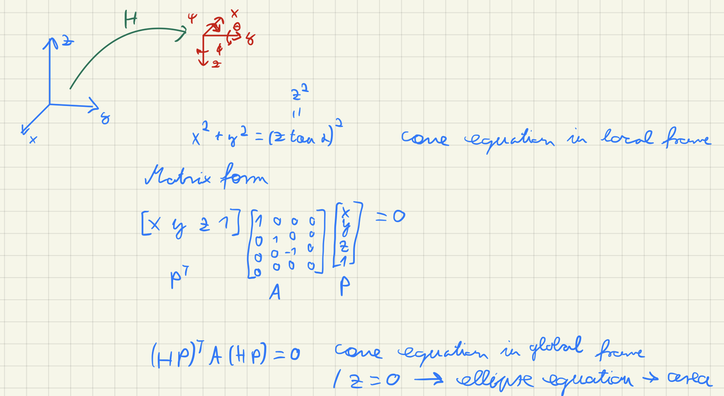

```python
Image("question_1_2.png")
```

```python
x, y, z, dx, dy, dz=symbols('x y z dx dy dz')
```

```python
#z and y pointing the same direction so x is -x, therefore -dx
#H_x ratation around X
```

```python
HR_X_G_psi=Matrix([[1,0,0,0],
                   [0,cos(psi),-sin(psi),0],
                   [0,sin(psi),cos(psi),0],
                  [0,0,0,1]])
HR_Y_G_theta=Matrix([[cos(theta),0,sin(theta),0],
                   [0,1,0,0],
                   [-sin(theta),0,cos(theta),0],
                    [0,0,0,1]])
HR_Z_G_phi=Matrix([[cos(phi),-sin(phi),0,0],
                   [sin(phi),cos(phi),0,0],
                   [0,0,1,0],
                  [0,0,0,1]])
T=Matrix([[1,0,0,-dx],
         [0,1,0,dy],
         [0,0,1,dz],
         [0,0,0,1]])
H_X=Matrix([[1,0,0,0],
            [0,-1,0,0],
            [0,0,-1,0],
            [0,0,0,1]])
H=simplify(T*H_X*HR_Z_G_phi*HR_Y_G_theta*HR_X_G_psi)
H
```

$\displaystyle \left[\begin{matrix}\cos{\left(\phi \right)} \cos{\left(\theta \right)} & - \sin{\left(\phi \right)} \cos{\left(\psi \right)} + \sin{\left(\psi \right)} \sin{\left(\theta \right)} \cos{\left(\phi \right)} & \sin{\left(\phi \right)} \sin{\left(\psi \right)} + \sin{\left(\theta \right)} \cos{\left(\phi \right)} \cos{\left(\psi \right)} & - dx\\- \sin{\left(\phi \right)} \cos{\left(\theta \right)} & - \sin{\left(\phi \right)} \sin{\left(\psi \right)} \sin{\left(\theta \right)} - \cos{\left(\phi \right)} \cos{\left(\psi \right)} & - \sin{\left(\phi \right)} \sin{\left(\theta \right)} \cos{\left(\psi \right)} + \sin{\left(\psi \right)} \cos{\left(\phi \right)} & dy\\\sin{\left(\theta \right)} & - \sin{\left(\psi \right)} \cos{\left(\theta \right)} & - \cos{\left(\psi \right)} \cos{\left(\theta \right)} & dz\\0 & 0 & 0 & 1\end{matrix}\right]$

The matrix representation of the cone equation in the local frame is created below.

```python
#cone equation
P=Matrix([x,y,z,1])
A=Matrix([[1,0,0,0],
        [0,1,0,0],
        [0,0,-1,0],
        [0,0,0,0]])
P.T*A*P
```

$\displaystyle \left[\begin{matrix}x^{2} + y^{2} - z^{2}\end{matrix}\right]$

The cone equation in the global frame is created below using the transformation matrix.

```python
exp=(simplify(((H*P).T*A*(H*P)).subs({z:0})))[0]
p=Poly(exp.evalf(),x,y,x*y,x**2,y**2)
p
```

$\displaystyle \operatorname{Poly}{\left( \left(\sin^{2}{\left(\phi \right)} \cos^{2}{\left(\theta \right)} - \sin^{2}{\left(\theta \right)} + \cos^{2}{\left(\phi \right)} \cos^{2}{\left(\theta \right)}\right) x^{2} + \left(2 \sin^{2}{\left(\phi \right)} \sin{\left(\psi \right)} \sin{\left(\theta \right)} \cos{\left(\theta \right)} + 2 \sin{\left(\psi \right)} \sin{\left(\theta \right)} \cos^{2}{\left(\phi \right)} \cos{\left(\theta \right)} + 2 \sin{\left(\psi \right)} \sin{\left(\theta \right)} \cos{\left(\theta \right)}\right) xy + \left(- 2 dx \cos{\left(\phi \right)} \cos{\left(\theta \right)} - 2 dy \sin{\left(\phi \right)} \cos{\left(\theta \right)} - 2 dz \sin{\left(\theta \right)}\right) x + \left(\sin^{2}{\left(\phi \right)} \sin^{2}{\left(\psi \right)} \sin^{2}{\left(\theta \right)} + \sin^{2}{\left(\phi \right)} \cos^{2}{\left(\psi \right)} + \sin^{2}{\left(\psi \right)} \sin^{2}{\left(\theta \right)} \cos^{2}{\left(\phi \right)} - \sin^{2}{\left(\psi \right)} \cos^{2}{\left(\theta \right)} + \cos^{2}{\left(\phi \right)} \cos^{2}{\left(\psi \right)}\right) y^{2} + \left(2 dx \sin{\left(\phi \right)} \cos{\left(\psi \right)} - 2 dx \sin{\left(\psi \right)} \sin{\left(\theta \right)} \cos{\left(\phi \right)} - 2 dy \sin{\left(\phi \right)} \sin{\left(\psi \right)} \sin{\left(\theta \right)} - 2 dy \cos{\left(\phi \right)} \cos{\left(\psi \right)} + 2 dz \sin{\left(\psi \right)} \cos{\left(\theta \right)}\right) y + dx^{2} + dy^{2} - dz^{2}, x, y, x y, x^{2}, y^{2}, domain=\mathtt{\text{EX}} \right)}$

Using the polinomial form of the equation in a plane - meaning $z$ has been set to 0- we can find the coefficients required for the calculation of the area.

```python
Param=Matrix([p.coeffs()[0],p.coeffs()[1],p.coeffs()[3],p.coeffs()[2],p.coeffs()[4],p.coeffs()[5]])
Param
```

$\displaystyle \left[\begin{matrix}\sin^{2}{\left(\phi \right)} \cos^{2}{\left(\theta \right)} - \sin^{2}{\left(\theta \right)} + \cos^{2}{\left(\phi \right)} \cos^{2}{\left(\theta \right)}\\2 \sin^{2}{\left(\phi \right)} \sin{\left(\psi \right)} \sin{\left(\theta \right)} \cos{\left(\theta \right)} + 2 \sin{\left(\psi \right)} \sin{\left(\theta \right)} \cos^{2}{\left(\phi \right)} \cos{\left(\theta \right)} + 2 \sin{\left(\psi \right)} \sin{\left(\theta \right)} \cos{\left(\theta \right)}\\\sin^{2}{\left(\phi \right)} \sin^{2}{\left(\psi \right)} \sin^{2}{\left(\theta \right)} + \sin^{2}{\left(\phi \right)} \cos^{2}{\left(\psi \right)} + \sin^{2}{\left(\psi \right)} \sin^{2}{\left(\theta \right)} \cos^{2}{\left(\phi \right)} - \sin^{2}{\left(\psi \right)} \cos^{2}{\left(\theta \right)} + \cos^{2}{\left(\phi \right)} \cos^{2}{\left(\psi \right)}\\- 2 dx \cos{\left(\phi \right)} \cos{\left(\theta \right)} - 2 dy \sin{\left(\phi \right)} \cos{\left(\theta \right)} - 2 dz \sin{\left(\theta \right)}\\2 dx \sin{\left(\phi \right)} \cos{\left(\psi \right)} - 2 dx \sin{\left(\psi \right)} \sin{\left(\theta \right)} \cos{\left(\phi \right)} - 2 dy \sin{\left(\phi \right)} \sin{\left(\psi \right)} \sin{\left(\theta \right)} - 2 dy \cos{\left(\phi \right)} \cos{\left(\psi \right)} + 2 dz \sin{\left(\psi \right)} \cos{\left(\theta \right)}\\dx^{2} + dy^{2} - dz^{2}\end{matrix}\right]$

The covered area can be ploted below.

```python
plot_p=(Param[0]*(x**2)+Param[1]*(x*y)+Param[2]*(y**2)+Param[3]*x+Param[4]*y+Param[5]).subs({psi:0,theta:0,phi:0,dx:2,dy:2,dz:1})
plot_p
```

$\displaystyle x^{2} - 4 x + y^{2} - 4 y + 7$

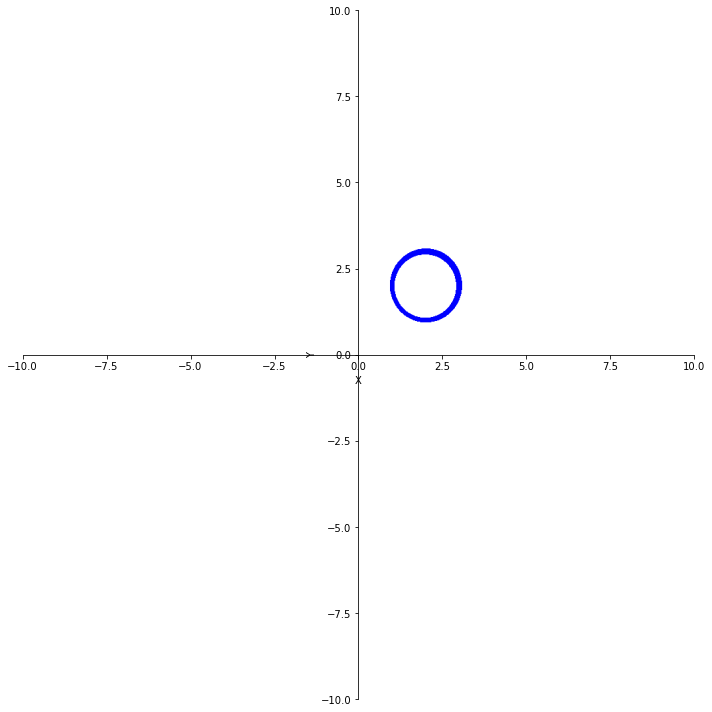

```
<sympy.plotting.plot.Plot at 0x18d6a650a00>
```

```python
plot_implicit(plot_p, x_var=(x,-10,10),y_var=(y,-10,10), xlabel="X", ylabel="Y")
```

```python
a=Param[0]
b=Param[1]/2
c=Param[2]
d=Param[3]/2
e=Param[4]/2
f=Param[5]
K=Matrix([[a,b,d],[b,c,e],[d,e,f]])
```

The area can be calculated using the given equation

```python
A=(-pi)/(sqrt(((a*c)-b**2)**3))*det(K)
simplify(A.subs({psi:0,theta:0,phi:0,dx:2,dy:2,dz:1}))
```

$\displaystyle \pi$

The result is accurate since the radius of the circle is equal to 1.

## 1.3 Transform Estimation

The position of P' is written up as the transformation of P using H.

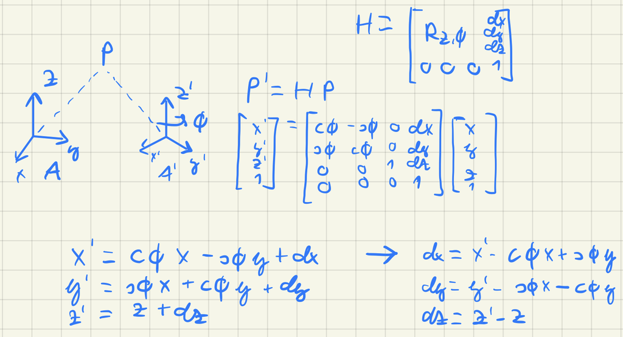

```python
Image("question_1_3.png")
```

Rotation around $Z$-axis with $\phi$ and translation along $X$, $Y$, $Z$ with $dx$, $dy$ and $dz$ respectively

```python
HR_Z_phi=Matrix([[cos(phi),-sin(phi),0,dx],
                   [sin(phi),cos(phi),0,dy],
                   [0,0,1,dz],
                   [0,0,0,1]])
HR_Z_phi
```

$\displaystyle \left[\begin{matrix}\cos{\left(\phi \right)} & - \sin{\left(\phi \right)} & 0 & dx\\\sin{\left(\phi \right)} & \cos{\left(\phi \right)} & 0 & dy\\0 & 0 & 1 & dz\\0 & 0 & 0 & 1\end{matrix}\right]$

Where $dx$, $dy$ and $dz$ are equal to the followings:

```python
dx=x_p-x*cos(phi)+y*sin(phi)
dx
```

$\displaystyle - x \cos{\left(\phi \right)} + x^{\prime} + y \sin{\left(\phi \right)}$

```python
dy=y_p-x*sin(phi)-y*cos(phi)
dy
```

$\displaystyle - x \sin{\left(\phi \right)} - y \cos{\left(\phi \right)} + y^{\prime}$

```python
dz=z_p-z
dz
```

$\displaystyle - z + z^{\prime}$

## 2.1 Trajectory Optimisation

First using the rotations given around $X, Y, Z$, based on that the symbolic rotation matrix can be calculated.

```python
HR_X_G_psi=Matrix([[1,0,0],
                   [0,cos(psi),-sin(psi)],
                   [0,sin(psi),cos(psi)]])
HR_Y_G_theta=Matrix([[cos(theta),0,sin(theta)],
                   [0,1,0],
                   [-sin(theta),0,cos(theta)]])
HR_Z_G_phi=Matrix([[cos(phi),-sin(phi),0],
                   [sin(phi),cos(phi),0],
                   [0,0,1]])
simplify(HR_Z_G_phi*HR_Y_G_theta*HR_X_G_psi).evalf()
```

$\displaystyle \left[\begin{matrix}\cos{\left(\phi \right)} \cos{\left(\theta \right)} & - \sin{\left(\phi \right)} \cos{\left(\psi \right)} + \sin{\left(\psi \right)} \sin{\left(\theta \right)} \cos{\left(\phi \right)} & \sin{\left(\phi \right)} \sin{\left(\psi \right)} + \sin{\left(\theta \right)} \cos{\left(\phi \right)} \cos{\left(\psi \right)}\\\sin{\left(\phi \right)} \cos{\left(\theta \right)} & \sin{\left(\phi \right)} \sin{\left(\psi \right)} \sin{\left(\theta \right)} + \cos{\left(\phi \right)} \cos{\left(\psi \right)} & \sin{\left(\phi \right)} \sin{\left(\theta \right)} \cos{\left(\psi \right)} - \sin{\left(\psi \right)} \cos{\left(\phi \right)}\\- \sin{\left(\theta \right)} & \sin{\left(\psi \right)} \cos{\left(\theta \right)} & \cos{\left(\psi \right)} \cos{\left(\theta \right)}\end{matrix}\right]$

We can plug in the given values.

```python
R=(((simplify(HR_Z_G_phi*HR_Y_G_theta*HR_X_G_psi))).subs({psi:(35/180*pi),theta:(15/180*pi),phi:(20/180*pi)})).evalf()
R
```

$\displaystyle \left[\begin{matrix}0.907673371190369 & -0.140666775591018 & 0.395400947743853\\0.330366089549352 & 0.820524878545215 & -0.466473118801319\\-0.258819045102521 & 0.554032293222323 & 0.791240115236224\end{matrix}\right]$

We can check that our calculation theta is accurate.

```python
(asin(-R[2,0])/pi*180).evalf()
```

$\displaystyle 15.0$

To achieve the smoothest rotation the drone rotates around one specific axis with a specific angle, that are results of its rotation around the local axises.From the transformation matrix R the Axis-Angle representation (using Rodriguez form) can be calculated. The required angle is $\nu$:

```python
nu=simplify(acos((trace(R)-1)/2)) #angle
(nu/pi*180).evalf() #deg
```

$\displaystyle 40.5605521115655$

Using R and $\nu$ the cross product tensor can be calculated.

```python
nx=simplify((R-R.T)/(2*sin(nu)))
nx
```

$\displaystyle \left[\begin{matrix}0 & -0.362192939275823 & 0.503051654519739\\0.362192939275823 & 0 & -0.784700775852614\\-0.503051654519739 & 0.784700775852614 & 0\end{matrix}\right]$

From the cross product tensor we can define the Axis $n$ that we are rotation around. The $X$ value is the [2,1] element, the $Y$ value is the [0,2] element, while the $Z$ value is the [1,0] element

```python
n = (Matrix([nx[2,1],nx[0,2],nx[1,0]]))
n #axis
```

$\displaystyle \left[\begin{matrix}0.784700775852614\\0.503051654519739\\0.362192939275823\end{matrix}\right]$

This axis needs to be an eigenvector, that is true, see below

```python
n.norm()
```

$\displaystyle 1.0$

Since we are rotation around a random axis the rotation around $X, Y, Z$ should end at the same time, therefore the largest distance to travel requires the highest angular velocity, so $\omega_x = 1 deg/s$, I am working with constant velocities.

```python
w_x=1/180*pi #rad/s
w_x.evalf()
```

$\displaystyle 0.0174532925199433$

The angular rotations in the global frame can be calculated from $\nu$ using the ratio defined by the axis ${\\}n$. Using the largest angular rotation and the coressponding maximum angular velocity we can calculate the time. Using $t$ and the calculated angular rotations $\omega_y,\omega_z$ are the following.

```python
psi_r=(n[0]*nu).evalf() #angular around local X
```

```python
t=psi_r/w_x.evalf()
t #s
```

$\displaystyle 31.8278967109558$

```python
theta_r=(n[1]*nu).evalf() #angular around local Y
```

```python
w_y=theta_r/t
w_y #rad/sec
```

$\displaystyle 0.0111888607086372$

```python
(w_y/pi*180).evalf() #deg/sec
```

$\displaystyle 0.641074496164668$

```python
phi_r=(n[2]*nu).evalf() #angular around local Z
```

```python
w_z=phi_r/t
w_z #rad/sec
```

$\displaystyle 0.00805588513783542$

```python
(w_z/pi*180).evalf() #deg/sec
```

$\displaystyle 0.461568218640135$

To check the calculations we can calculate $\omega_k$ the angular velocity around $n$ in two different ways - as a vectorial sum of $\omega_x,\omega_y,\omega_z$ or dividing ${\\nu}$ with $t$ and the results should be the same, which is true.

```python
sqrt(w_x**2+w_y**2+w_z**2).evalf() #rad/s
```

$\displaystyle 0.022241971789794$

```python
w_k=nu/t
w_k #rad/s
```

$\displaystyle 0.022241971789794$

```python
nu/w_k
```

$\displaystyle 31.8278967109558$

```python
(w_k/pi*180).evalf() #deg/sec
```

$\displaystyle 1.27437111160423$

The general form of the rotation matrix can be written up using Axis-Angle representation

```python
gamma, u_x, u_y, u_z=symbols('gamma u_x u_y u_z')
u=Matrix([u_x,u_y,u_z])
konst=(1-cos(gamma))
```

```python
R_Axis_Angle=Matrix([[cos(gamma)+(u[0]**2)*konst, u[0]*u[1]*konst-u[2]*sin(gamma), u[0]*u[2]*konst+u[1]*sin(gamma)],
                    [u[1]*u[0]*konst+u[2]*sin(gamma), cos(gamma)+(u[1]**2)*konst, u[1]*u[2]*konst-u[0]*sin(gamma)],
                    [u[2]*u[0]*konst-u[1]*sin(gamma), u[2]*u[1]*konst+u[0]*sin(gamma), cos(gamma)+(u[2]**2)*konst]])
R_Axis_Angle
```

$\displaystyle \left[\begin{matrix}u_{x}^{2} \cdot \left(1 - \cos{\left(\gamma \right)}\right) + \cos{\left(\gamma \right)} & u_{x} u_{y} \left(1 - \cos{\left(\gamma \right)}\right) - u_{z} \sin{\left(\gamma \right)} & u_{x} u_{z} \left(1 - \cos{\left(\gamma \right)}\right) + u_{y} \sin{\left(\gamma \right)}\\u_{x} u_{y} \left(1 - \cos{\left(\gamma \right)}\right) + u_{z} \sin{\left(\gamma \right)} & u_{y}^{2} \cdot \left(1 - \cos{\left(\gamma \right)}\right) + \cos{\left(\gamma \right)} & - u_{x} \sin{\left(\gamma \right)} + u_{y} u_{z} \left(1 - \cos{\left(\gamma \right)}\right)\\u_{x} u_{z} \left(1 - \cos{\left(\gamma \right)}\right) - u_{y} \sin{\left(\gamma \right)} & u_{x} \sin{\left(\gamma \right)} + u_{y} u_{z} \left(1 - \cos{\left(\gamma \right)}\right) & u_{z}^{2} \cdot \left(1 - \cos{\left(\gamma \right)}\right) + \cos{\left(\gamma \right)}\end{matrix}\right]$

```python
B=R_Axis_Angle.subs({gamma:w_k*t,u_x:n[0],u_y:n[1],u_z:n[2]})
```

We can check the angular rotation values using R and R_Axis_Angle.

```python
simplify(HR_Z_G_phi*HR_Y_G_theta*HR_X_G_psi).evalf() #R
```

$\displaystyle \left[\begin{matrix}\cos{\left(\phi \right)} \cos{\left(\theta \right)} & - \sin{\left(\phi \right)} \cos{\left(\psi \right)} + \sin{\left(\psi \right)} \sin{\left(\theta \right)} \cos{\left(\phi \right)} & \sin{\left(\phi \right)} \sin{\left(\psi \right)} + \sin{\left(\theta \right)} \cos{\left(\phi \right)} \cos{\left(\psi \right)}\\\sin{\left(\phi \right)} \cos{\left(\theta \right)} & \sin{\left(\phi \right)} \sin{\left(\psi \right)} \sin{\left(\theta \right)} + \cos{\left(\phi \right)} \cos{\left(\psi \right)} & \sin{\left(\phi \right)} \sin{\left(\theta \right)} \cos{\left(\psi \right)} - \sin{\left(\psi \right)} \cos{\left(\phi \right)}\\- \sin{\left(\theta \right)} & \sin{\left(\psi \right)} \cos{\left(\theta \right)} & \cos{\left(\psi \right)} \cos{\left(\theta \right)}\end{matrix}\right]$

```python
theta_2=asin(-B[2,0])
(theta_2/pi*180).evalf()
```

$\displaystyle 15.0$

```python
phi_2=acos(B[0,0]/cos(theta_2))/pi*180
phi_2.evalf()
```

$\displaystyle 20.0$

```python
psi_2=acos(B[2,2]/cos(theta_2))/pi*180
psi_2.evalf()
```

$\displaystyle 35.0$

The angular velocities around the local axises and the angular rotations in the global frame can be plotted over time.

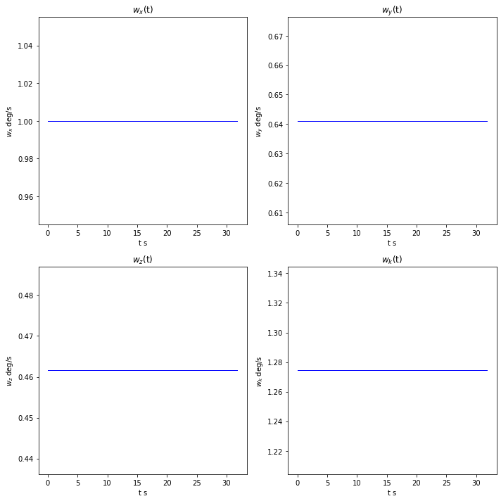

```python
plt.rcParams['figure.figsize'] = [10, 10]
sampling=[]
a_velocity_x=[]
a_velocity_y=[]
a_velocity_z=[]
a_velocity_k=[]
for i in range(0,int(t)):
    sampling.append(i)
    a_velocity_x.append(((w_x/pi*180).evalf()))
    a_velocity_y.append(((w_y/pi*180).evalf()))
    a_velocity_z.append(((w_z/pi*180).evalf()))
    a_velocity_k.append(((w_k/pi*180).evalf()))

sampling.append(t)
a_velocity_x.append(((w_x/pi*180).evalf()))
a_velocity_y.append(((w_y/pi*180).evalf()))
a_velocity_z.append(((w_z/pi*180).evalf()))
a_velocity_k.append(((w_k/pi*180).evalf()))
plt.subplot(2, 2, 1)
plt.plot(sampling, a_velocity_x, color='blue', linestyle='solid', linewidth = 1)
plt.title("$w_x$(t)")
plt.xlabel("t s")
plt.ylabel("$w_x$ deg/s")

plt.subplot(2, 2, 2)
plt.plot(sampling, a_velocity_y, color='blue', linestyle='solid', linewidth = 1)
plt.title("$w_y$(t)")
plt.xlabel("t s")
plt.ylabel("$w_y$ deg/s")

plt.subplot(2, 2, 3)
plt.plot(sampling, a_velocity_z, color='blue', linestyle='solid', linewidth = 1)
plt.title("$w_z$(t)")
plt.xlabel("t s")
plt.ylabel("$w_z$ deg/s")

plt.subplot(2, 2, 4)
plt.plot(sampling, a_velocity_k, color='blue', linestyle='solid', linewidth = 1)
plt.title("$w_k$(t)")
plt.xlabel("t s")
plt.ylabel("$w_k$ deg/s")
plt.tight_layout()
```

The angular rotation values seem reasonable since $\nu$ is linear and the others are pretty close to linear.

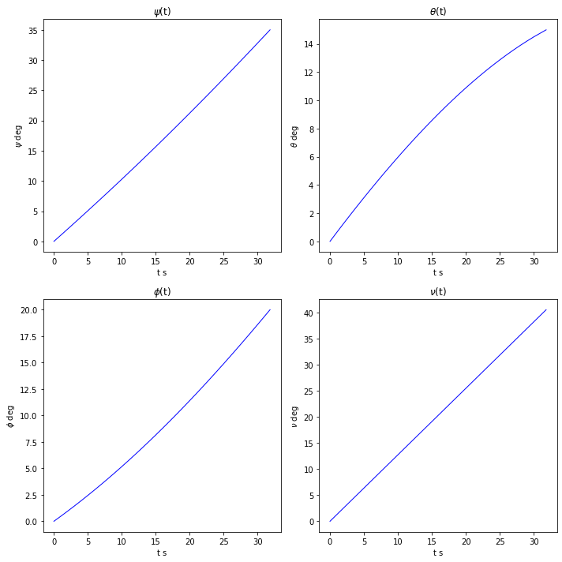

```python
B=R_Axis_Angle.subs({u_x:n[0],u_y:n[1],u_z:n[2]})
plt.rcParams['figure.figsize'] = [10, 10]
sampling=[]
psi_in_t=[]
theta_in_t=[]
phi_in_t=[]
nu_in_t=[]
for i in range(0,int(t)):
    B=R_Axis_Angle.subs({u_x:n[0],u_y:n[1],u_z:n[2]})
    sampling.append(i)
    nu=i*w_k
    B=B.subs({gamma:nu})
    theta_2=(asin(-B[2,0])).evalf()

    phi_in_t.append((acos(B[0,0]/cos(theta_2))/pi*180).evalf())
    psi_in_t.append((acos(B[2,2]/cos(theta_2))/pi*180).evalf())
    theta_in_t.append((theta_2/pi*180).evalf())
    nu_in_t.append(nu/pi*180)
B=R_Axis_Angle.subs({u_x:n[0],u_y:n[1],u_z:n[2]})
sampling.append(t)
nu=t*w_k
B=B.subs({gamma:nu})
theta_2=(asin(-B[2,0])).evalf()

phi_in_t.append((acos(B[0,0]/cos(theta_2))/pi*180).evalf())
psi_in_t.append((acos(B[2,2]/cos(theta_2))/pi*180).evalf())
theta_in_t.append((theta_2/pi*180).evalf())
nu_in_t.append(nu/pi*180)

plt.subplot(2, 2, 1)
plt.plot(sampling, psi_in_t, color='blue', linestyle='solid', linewidth = 1)
plt.title("$\psi$(t)")
plt.xlabel("t s")
plt.ylabel("$\psi$ deg")

plt.subplot(2, 2, 2)
plt.plot(sampling, theta_in_t, color='blue', linestyle='solid', linewidth = 1)
plt.title("$\\theta$(t)")
plt.xlabel("t s")
plt.ylabel("$\\theta$ deg")

plt.subplot(2, 2, 3)
plt.plot(sampling, phi_in_t, color='blue', linestyle='solid', linewidth = 1)
plt.title("$\phi$(t)")
plt.xlabel("t s")
plt.ylabel("$\phi$ deg")



plt.subplot(2, 2, 4)
plt.plot(sampling, nu_in_t, color='blue', linestyle='solid', linewidth = 1)
plt.title("$\\nu$(t)")
plt.xlabel("t s")
plt.ylabel("$\\nu$ deg")
plt.tight_layout()
```